# Capstone 2022

Autumn Smith

3/11/2022

## read in data

```r
if (!require("ipumsr")) stop("Reading IPUMS data into R requires the ipumsr package. It can be installed using the following command: install.packages('ipumsr')")
ddi <- read_ipums_ddi("meps_00001.xml")
DATA <- read_ipums_micro(ddi)
```

```
## Use of data from IPUMS MEPS is subject to conditions including that users
## should cite the data appropriately. Use command `ipums_conditions()` for more
## details.
```

```r
data <- DATA[DATA$YEAR==2017,]  # making a copy of data in the year 2017 for EDA
head(data)
```

```
## # A tibble: 6 x 81
##    YEAR PERNUM  DUID PID   MEPSID PANEL PSUANN STRATANN PSUPLD STRATAPLD PANELYR
##   <dbl>  <dbl> <dbl> <chr> <chr>  <int> <dbl+> <dbl+lb> <dbl+> <dbl+lbl>   <int>
## 1  2017      1 10001 101   21100~ 21 []      1     1021     NA        NA    2016
## 2  2017      2 10001 102   21100~ 21 []      1     1021     NA        NA    2016
## 3  2017      3 10001 103   21100~ 21 []      1     1021     NA        NA    2016
## 4  2017      4 10001 104   21100~ 21 []      1     1021     NA        NA    2016
## 5  2017      1 10002 101   21100~ 21 []      1     1077     NA        NA    2016
## 6  2017      2 10002 102   21100~ 21 []      1     1077     NA        NA    2016
## # ... with 70 more variables: RELYR <int+lbl>, PERWEIGHT <dbl>,
## #   SAQWEIGHT <dbl>, DIABWEIGHT <dbl>, SUPP1WT <dbl>, AGE <dbl+lbl>,
## #   SEX <int+lbl>, MARSTAT <int+lbl>, RACEA <int+lbl>, HISPETH <int+lbl>,
## #   YRSINUSG <int+lbl>, USBORN <int+lbl>, EDUC <int+lbl>, EDUCYR <int+lbl>,
## #   STUDENT <int+lbl>, HIDEG <int+lbl>, POVCAT <int+lbl>, POVLEV <dbl>,
## #   VISITYRNO <int+lbl>, USUALPL <int+lbl>, TYPUSCTRANS <int+lbl>,
## #   USCTRVLTIM <int+lbl>, EZINFOFREQ <int+lbl>, HINOTCOV <int+lbl>, ...
```

## preparing response variable

The variable of interest is “EXPSELFPAY” – how much is an individual expected to pay towards healthcare expenses in the year 2017.

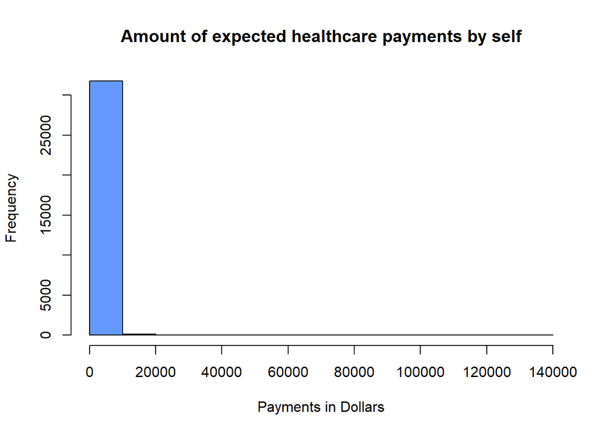

```r
hist(data$EXPSELFPAY,
     main = "Amount of expected healthcare payments by self",
     xlab = "Payments in Dollars",
     col="#6699FF")
```

We can see that the data is strongly skewed, and in need of a transformation in order to be interpretable. I will perform a log transformation of the income data.

```r
data$logEXPSELFPAY <- log(data$EXPSELFPAY+1)
```

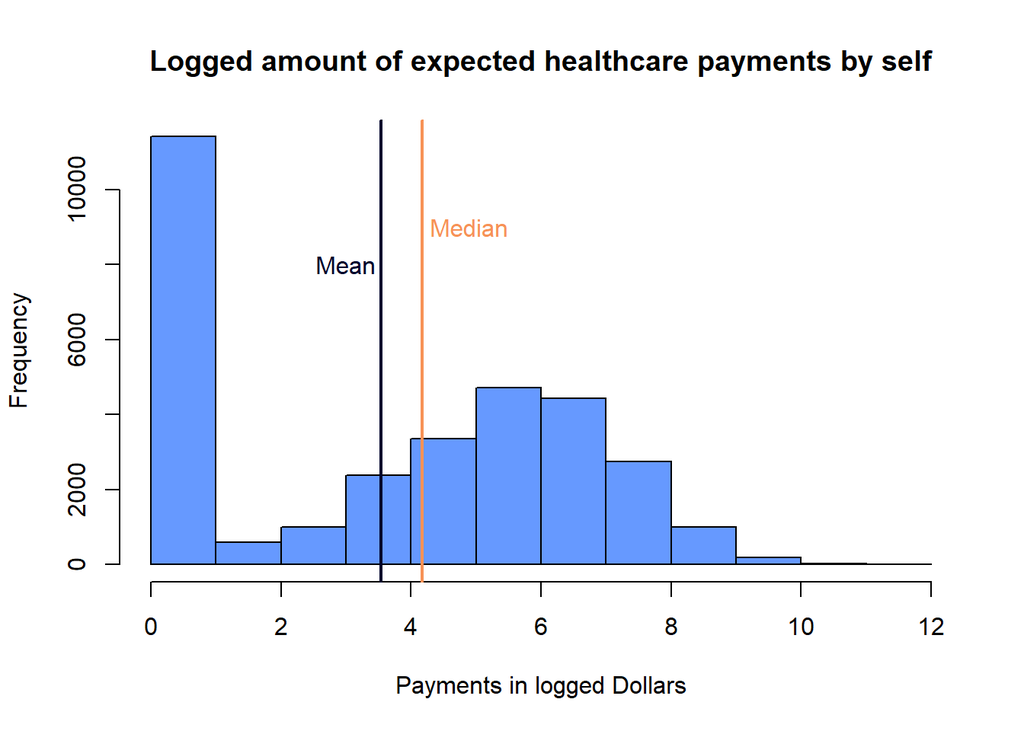

```r
mean <- mean(data$logEXPSELFPAY)
median <- median(data$logEXPSELFPAY)
hist(data$logEXPSELFPAY,
     main = "Logged amount of expected healthcare payments by self",
     xlab = "Payments in logged Dollars",
     col="#6699FF")
abline(v = mean, col = '#00032c', lwd = 2)
abline(v = median, col = '#f79256', lwd = 2)
text(4.9, 9000, "Median", col = '#f79256')
text(3, 8000, "Mean", col = '#00032c')
```

Now, we can see that the data appears to be more normal, with a spike around zero dollars. The mean is 3.53 logged dollars, which equates to about 34 dollars. The median is 4.17, or around 65 dollars.

## Data Cleaning

Twelve features and one outcome variable have been selected for the model.

```r
d1.cols <- c("logEXPSELFPAY", "MARSTAT", "AGE","EDUC", "SEX", "RACEA", "HISPETH", "VISITYRNO","POVCAT", "USCTRVLTIM", "HINOTCOV", "HIPRIVATE", "ADILCR")
d1 <- data[,d1.cols]
```

In the original dataset, NA values are listed as a large value starting with the digit 9 (i.e. 996, 998, 99, etc.). In the following steps, values that should actually be NA values are cleaned, and the appropriate features are set as factor variables, instead of numeric variables. All but logEXPSELFPAY and AGE are set as factors. Some of the features have no NA values that need to be cleaned, so that step is not present.

```r
d1$MARSTAT <- ifelse(d1$MARSTAT == 0 | d1$MARSTAT == 99, NA,d1$MARSTAT)
d1$MARSTAT <- as.factor(d1$MARSTAT)
summary(d1$MARSTAT)
```

```
##    10    20    30    40    50  NA's
## 11513  1592  2959   622  8022  7172
```

```r
d1$AGE <- ifelse(d1$AGE > 85, NA, d1$AGE)
summary(d1$AGE)
```

```
##    Min. 1st Qu.  Median    Mean 3rd Qu.    Max.    NA's
##    0.00   17.00   37.00   37.69   56.00   85.00     204
```

```r
d1$EDUC <- ifelse(d1$EDUC == 0 | d1$EDUC > 504, NA, d1$EDUC)
d1$EDUC <- as.factor(d1$EDUC)
summary(d1$EDUC)
```

```
##  102  104  105  106  107  108  109  110  111  113  114  115  116  201  202  301
## 1074  592  578  606  567  571  895  616  871  963  937 1130  392 6569  932 3519
##  400  501  503  504 NA's
## 3986 1768  475 1951 2888
```

```r
d1$SEX <- as.factor(d1$SEX)
summary(d1$SEX)
```

```
##     1     2
## 15166 16714
```

```r
d1$RACEA <- ifelse(d1$RACEA > 899, NA, d1$RACEA)
d1$RACEA <- as.factor(d1$RACEA)
summary(d1$RACEA)
```

```
##   100   200   310   410   420   610   611   612   613   614   615   616   617
## 22551  5683   219  1988   111    45    35   252   114   494   362    24     2
```

No NA values to be cleaned for HISPETH

```r
d1$HISPETH <- as.factor(d1$HISPETH)
summary(d1$HISPETH)
```

```
##    10    20    30    40    50    60    61    70
## 22752  5644   780   363   280   473  1354   234
```

```r
d1$VISITYRNO <- ifelse(d1$VISITYRNO > 40, NA, d1$VISITYRNO)
d1$VISITYRNO <- as.factor(d1$VISITYRNO)
summary(d1$VISITYRNO)
```

```
##    0   10   21   22   31   33   40 NA's
## 8353 5797 4545 2829 2175 2837 1651 3693
```

```r
d1$POVCAT <- as.factor(d1$POVCAT)
summary(d1$POVCAT)
```

```
##    1    2    3    4    5
## 6412 1806 4933 8892 9837
```

```r
d1$USCTRVLTIM <- ifelse(d1$USCTRVLTIM == 0 | d1$USCTRVLTIM > 6, NA, d1$USCTRVLTIM)
d1$USCTRVLTIM <- as.factor(d1$USCTRVLTIM)
summary(d1$USCTRVLTIM)
```

```
##     1     2     3     4     5     6  NA's
## 12556  9151  1969   210    62    71  7861
```

```r
d1$HINOTCOV<- ifelse(d1$HINOTCOV == 0 | d1$HINOTCOV > 2, NA, d1$HINOTCOV)
d1$HINOTCOV <- as.factor(d1$HINOTCOV)
summary(d1$HINOTCOV)
```

```
##     1     2
## 29029  2851
```

```r
d1$HIPRIVATE <- as.factor(d1$HIPRIVATE)
summary(d1$HIPRIVATE)
```

```
##     1     2
## 14408 17472
```

```r
d1$ADILCR <- ifelse(d1$ADILCR == 0 | d1$ADILCR > 2, NA, d1$ADILCR)
d1$ADILCR <- as.factor(d1$ADILCR)
summary(d1$ADILCR)
```

```
##     1     2  NA's
## 21453  6662  3765
```

## EDA: exploratory data analysis

First, we remove any rows with missing values.

```r
d <- d1
d <- d[complete.cases(d),]
```

The first variable we consider is AGE; age is capped at a low of 15 and at a high of 85. No individual under the age of 15 was surveyed, and any individual over 85 was marked to be 85.

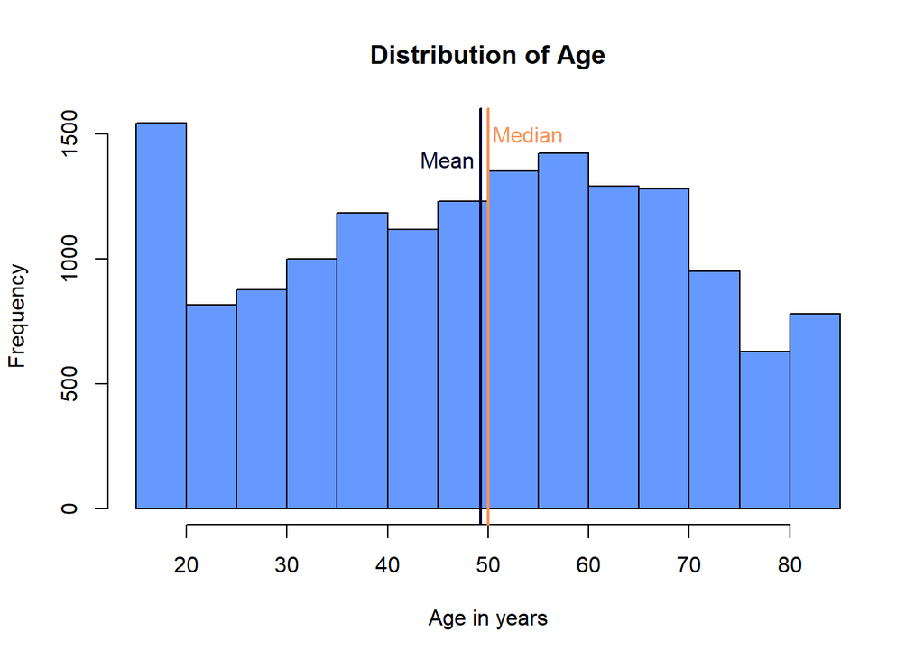

```r
mean <- mean(d$AGE)
median <- median(d$AGE)
hist(d$AGE,
     main = "Distribution of Age",
     xlab = "Age in years",
     col="#6699FF")
abline(v = mean, col = '#00032c', lwd = 2)
abline(v = median, col = '#f79256', lwd = 2)
text(54, 1500, "Median", col = '#f79256')
text(46, 1400, "Mean", col = '#00032c')
```

Age appears somewhat normal with a large spike of individuals between the age of 15 and 20. Next, we consider age versus our outcome, expected healthcare payments.

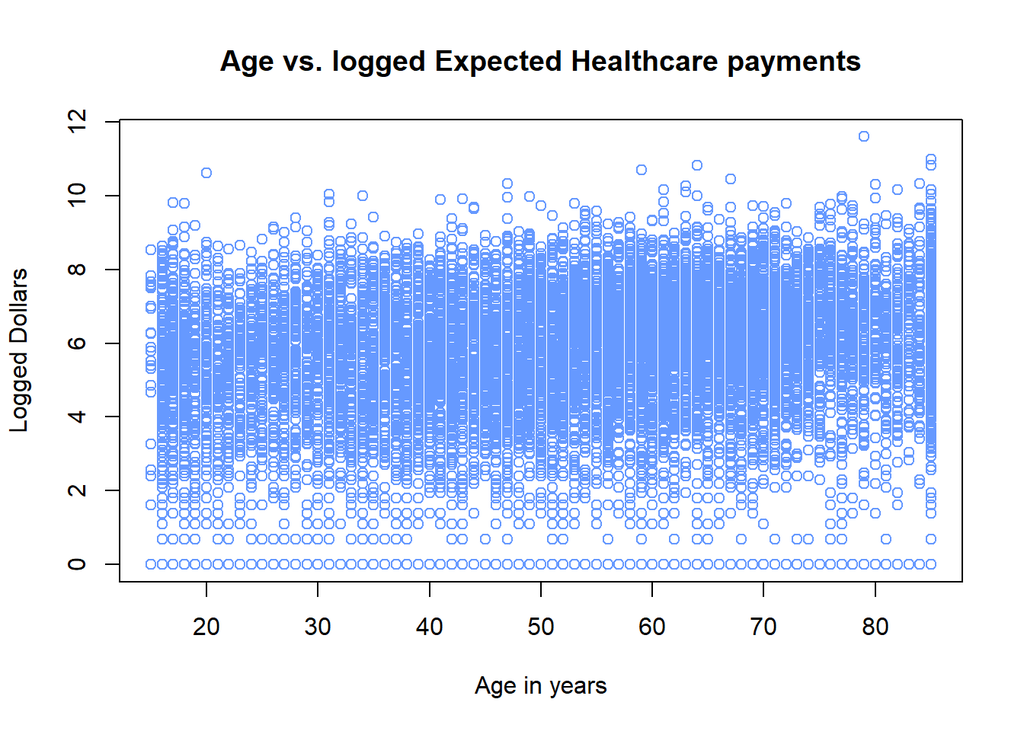

```r
plot(d$AGE,d$logEXPSELFPAY,
     main = "Age vs. logged Expected Healthcare payments",
     xlab = "Age in years",
     ylab = "Logged Dollars",
     col="#6699FF")
```

There does not appear to be a strong relationship between age and logged dollars. For each possible age, there is a wide spread of expected healthcare payments.

```r
cor(d$AGE,d$logEXPSELFPAY)
```

```
## [1] 0.3802681
```

The correlation between age and logged expected payments is 0.38, so it appears that there is light, positive correlation.

Now, we consider the variable EDUC, which represents level of education a unit received.

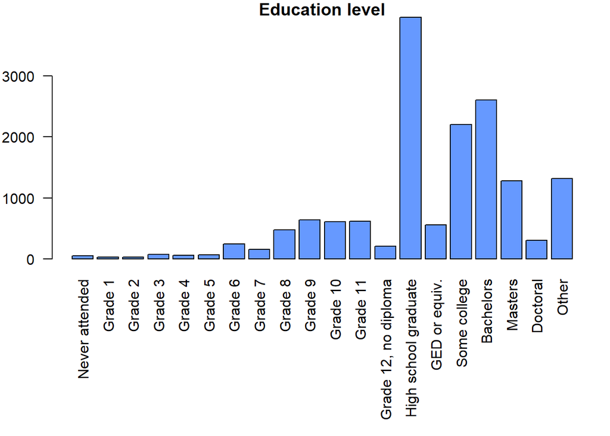

```r
xlabs <- c("Never attended","Grade 1", "Grade 2",
           "Grade 3", "Grade 4", "Grade 5",
           "Grade 6", "Grade 7", "Grade 8", "Grade 9",
           "Grade 10", "Grade 11", "Grade 12, no diploma",
           "High school graduate", "GED or equiv.",
           "Some college", "Bachelors",
           "Masters","Doctoral", "Other"
           )
par(mar=c(10, 3, 1, 1))
plot(d$EDUC, las = 2, names.arg = xlabs, col="#6699FF",
     main = "Education level")
```

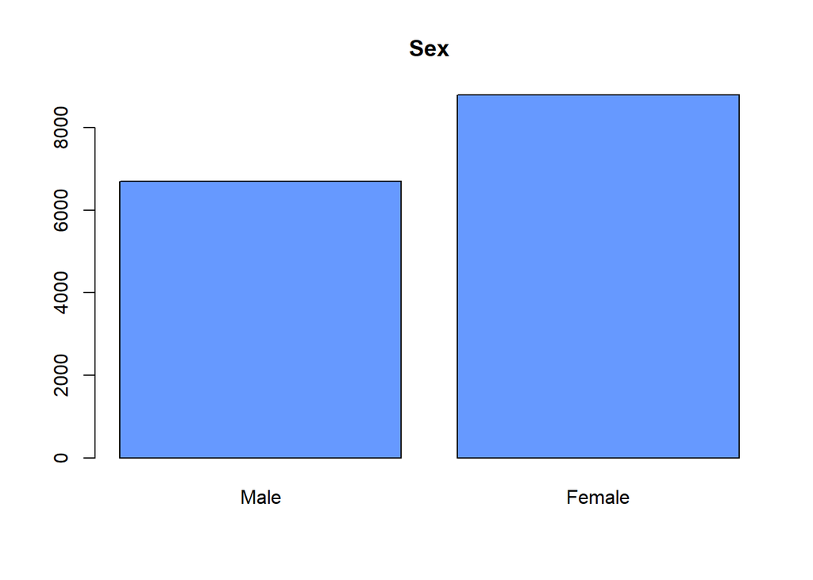

```r
plot(d$SEX, names.arg=c("Male", "Female"),  col="#6699FF",
     main = "Sex")
```

Of those surveyed, 43.2% identify as male, and 56.7% identify as female. In the year 2017, no surveyed individual chose to identify as a sex or gender other than male or female.

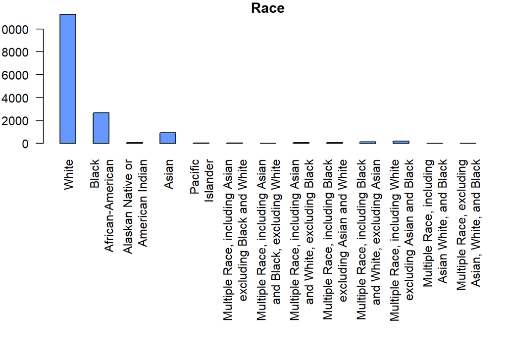

```r
xlabs <- c("White", "Black\nAfrican-American",
           "Alaskan Native or\nAmerican Indian",
           "Asian", "Pacific\nIslander",
           "Multiple Race, including Asian\nexcluding Black and White",
           "Multiple Race, including Asian\nand Black, excluding White",
           "Multiple Race, including Asian\nand White, excluding Black",
           "Multiple Race, including Black\nexcluding Asian and White",
           "Multiple Race, including Black\nand White, excluding Asian",
           "Multiple Race, including White\nexcluding Asian and Black",
           "Multiple Race, including\nAsian White, and Black",
           "Multiple Race, excluding\nAsian, White, and Black"

           )
space <- rep(c(1.1), times=length(xlabs))
par(mar=c(15,3,1,1))
plot(d$RACEA, las = 2,names.arg=xlabs, col="#6699FF",
     main = "Race", space = space)
```

Out of all surveyed individuals, 72.8% identify as white. Only 17.2% identify as Black or African-American, and only 6% identify as Asian. All other race breakdowns amount to 3.9%. Thus, our survey primarily reflects the opinions of white individuals, and any results we derive should be carefully considered with that in mind.

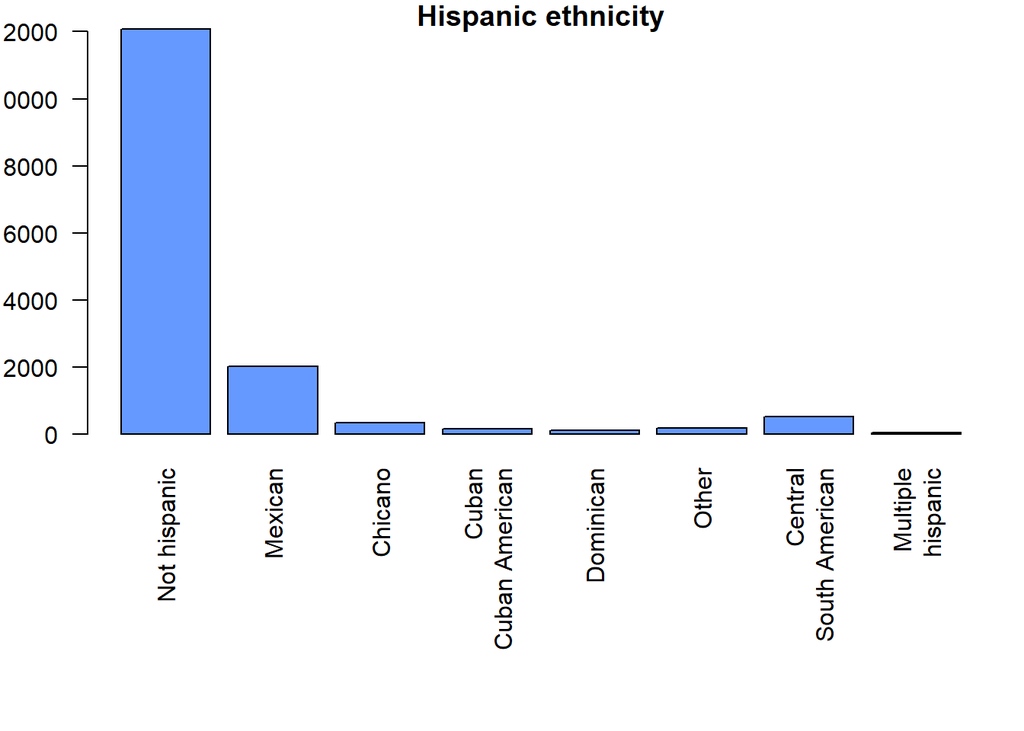

```r
xlabs <- c("Not hispanic", "Mexican", "Chicano", "Cuban\nCuban American", "Dominican", "Other", "Central\nSouth American", "Multiple\nhispanic")
par(mar=c(10, 3, 1, 1))
plot(d$HISPETH, las = 2, col="#6699FF", names.arg = xlabs,
     main = "Hispanic ethnicity")
```

Out of the survey, 21.9% of individuals identify as Hispanic, with the majority of those identifying as Mexican.

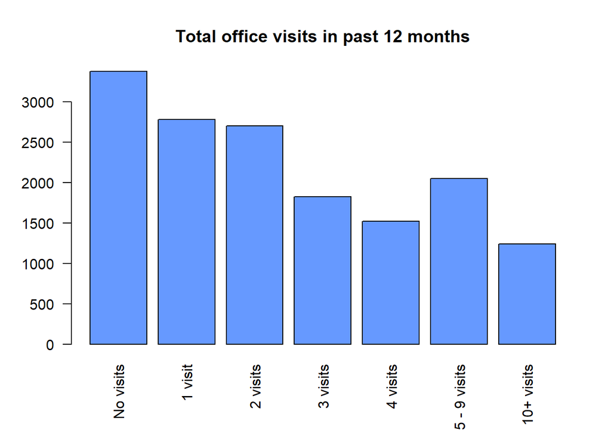

```r
xlabs <- c("No visits", "1 visit", "2 visits", "3 visits", "4 visits", "5 - 9 visits", "10+ visits")
plot(d$VISITYRNO, las = 2, col="#6699FF", names.arg = xlabs,
     main = "Total office visits in past 12 months")
```

21.7% of surveyed people had no medical office visits in the past 12 months. Out of those who did have an office visit, the majority had between one to three visits.

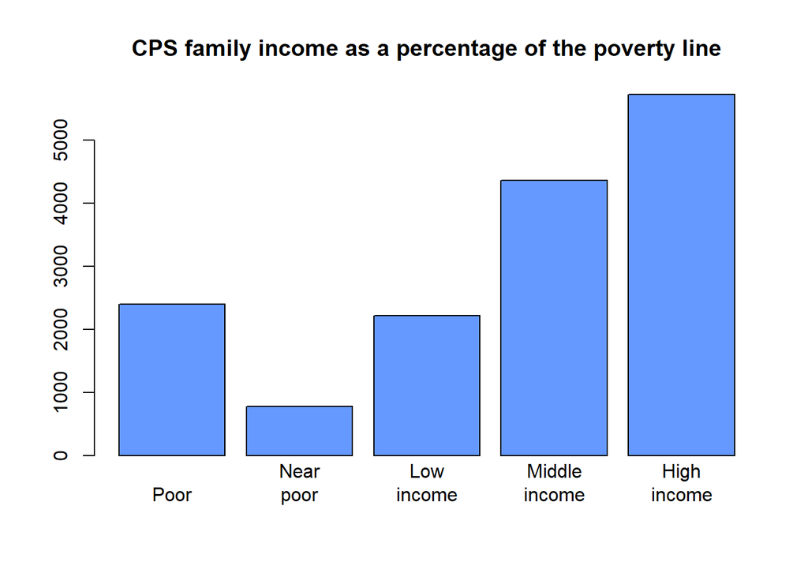

```r
plot(d$POVCAT,
     names.arg = c("Poor", "Near\npoor", "Low\nincome", "Middle\nincome", "High\nincome"),
     main = "CPS family income as a percentage of the poverty line",col="#6699FF")
```

Out of all surveyed individuals, 36.9% are in the high income category, which is at or greater than 400% of the poverty line. For a four-person household in 2017, this level is at around an annual income of $98400 (or, $48,240 for a one-person household). Over half of all survey respondents, 65.1%, are in middle or high income brackets; middle income being between 200-399% of the poverty line. 20.5% of respondents were at the poverty line, or below it. For a four-person household, this threshold is at $24,600 (or $12,060 for a one-person household).

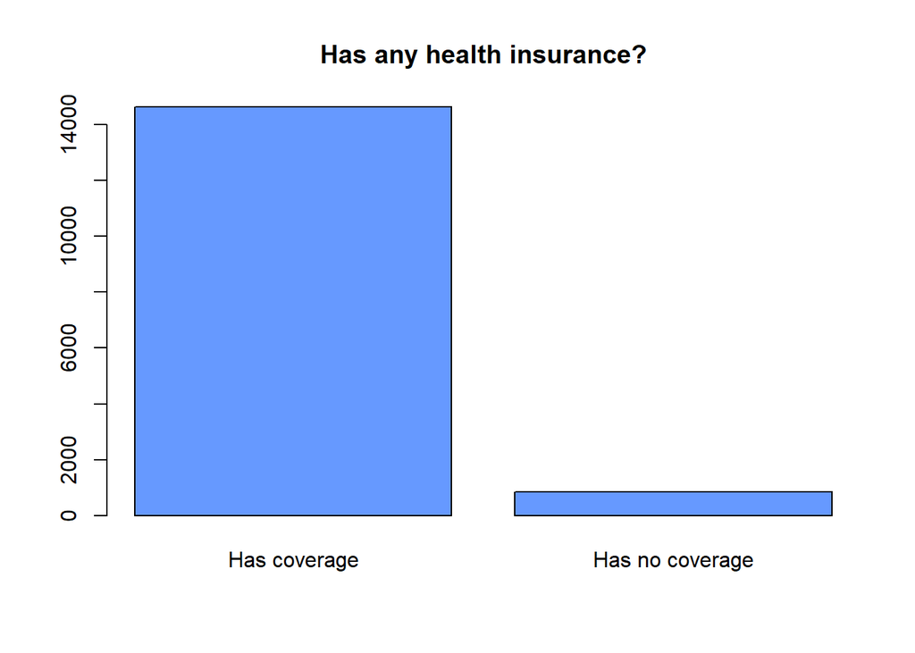

```r
plot(d$HINOTCOV, names.arg = c("Has coverage", "Has no coverage"),
     main = "Has any health insurance?",col="#6699FF")
```

A large majority of respondents, 94.5%, have some form of health insurance.

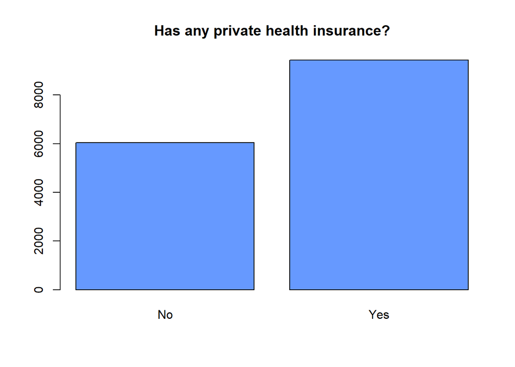

```r
plot(d$HIPRIVATE, names.arg=c("No", "Yes"),
     main = "Has any private health insurance?", col="#6699FF")
```

A majority, 60.9%, of respondents have some form of private insurance.

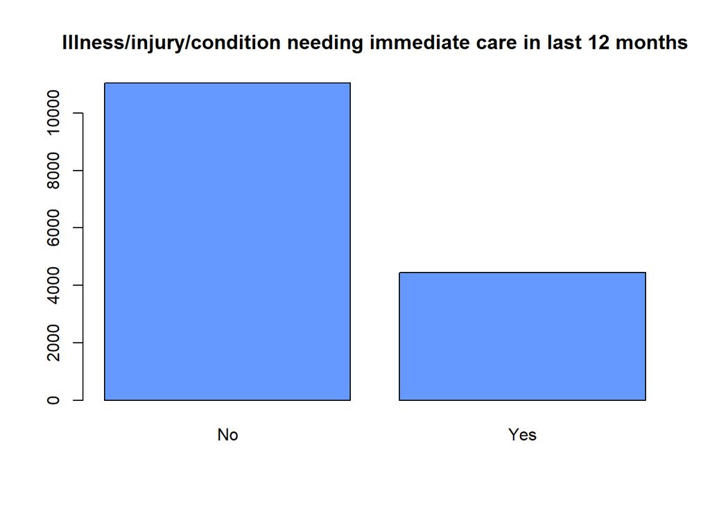

```r
xlabs <- c("No", "Yes")
plot(d$ADILCR, names.arg = xlabs,
     main = "Illness/injury/condition needing immediate care in last 12 months",
     col="#6699FF")
```

Most individuals, 71.3%, did not sustain an illness, injury, or condition that needed immediate care in the last 12 months.

## Model building

Our response is the logged expected healthcare payments, and all features are considered in the first model.

```r
reg1 <- lm(logEXPSELFPAY~., data=d)
summary(reg1)
```

```
##
## Call:
## lm(formula = logEXPSELFPAY ~ ., data = d)
##
## Residuals:
##     Min      1Q  Median      3Q     Max
## -7.7813 -1.2779  0.2173  1.4226  8.3205
##
## Coefficients:
##              Estimate Std. Error t value Pr(>|t|)
## (Intercept) -0.310550   0.318520  -0.975  0.32959
## MARSTAT20    0.091647   0.072301   1.268  0.20497
## MARSTAT30    0.141562   0.054929   2.577  0.00997 **
## MARSTAT40    0.050899   0.116059   0.439  0.66098
## MARSTAT50    0.026741   0.050813   0.526  0.59871
## AGE          0.038167   0.001255  30.404  < 2e-16 ***
## EDUC104     -0.316423   0.494452  -0.640  0.52222
## EDUC105      0.068006   0.470354   0.145  0.88504
## EDUC106      0.361851   0.387738   0.933  0.35071
## EDUC107      0.225397   0.408220   0.552  0.58086
## EDUC108      0.174798   0.392944   0.445  0.65644
## EDUC109      0.078371   0.328805   0.238  0.81161
## EDUC110      0.211003   0.344645   0.612  0.54039
## EDUC111      0.174017   0.316111   0.550  0.58199
## EDUC113      0.266959   0.312522   0.854  0.39300
## EDUC114      0.330946   0.313223   1.057  0.29072
## EDUC115      0.228832   0.313140   0.731  0.46493
## EDUC116      0.194051   0.334300   0.580  0.56161
## EDUC201      0.271845   0.303217   0.897  0.36998
## EDUC202      0.200703   0.314321   0.639  0.52314
## EDUC301      0.454470   0.305027   1.490  0.13626
## EDUC400      0.673847   0.305338   2.207  0.02734 *
## EDUC501      0.696569   0.308567   2.257  0.02400 *
## EDUC503      0.750570   0.326000   2.302  0.02133 *
## EDUC504      0.482250   0.307563   1.568  0.11691
## SEX2         0.318193   0.035208   9.038  < 2e-16 ***
## RACEA200    -0.644947   0.048458 -13.309  < 2e-16 ***
## RACEA310    -0.337059   0.243869  -1.382  0.16695
## RACEA410    -0.751012   0.073738 -10.185  < 2e-16 ***
## RACEA420    -0.062643   0.312424  -0.201  0.84109
```

[output cut: 23 more lines]

```
## POVCAT5      0.966829   0.062426  15.488  < 2e-16 ***
## USCTRVLTIM2  0.026848   0.036365   0.738  0.46035
## USCTRVLTIM3  0.033599   0.063296   0.531  0.59556
## USCTRVLTIM4 -0.117781   0.183547  -0.642  0.52108
## USCTRVLTIM5  0.456213   0.307055   1.486  0.13736
## USCTRVLTIM6  0.386907   0.288673   1.340  0.18017
## HINOTCOV2    1.147923   0.081754  14.041  < 2e-16 ***
## HIPRIVATE2   1.099333   0.044229  24.856  < 2e-16 ***
## ADILCR2      0.445498   0.040159  11.093  < 2e-16 ***
## ---
## Signif. codes:  0 '***' 0.001 '**' 0.01 '*' 0.05 '.' 0.1 ' ' 1
##
## Residual standard error: 2.109 on 15427 degrees of freedom
## Multiple R-squared:  0.3805, Adjusted R-squared:  0.378
## F-statistic: 155.3 on 61 and 15427 DF,  p-value: < 2.2e-16
```

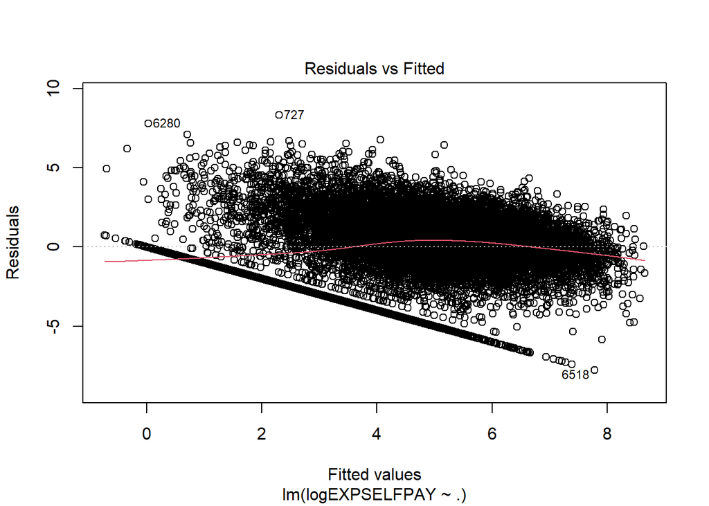

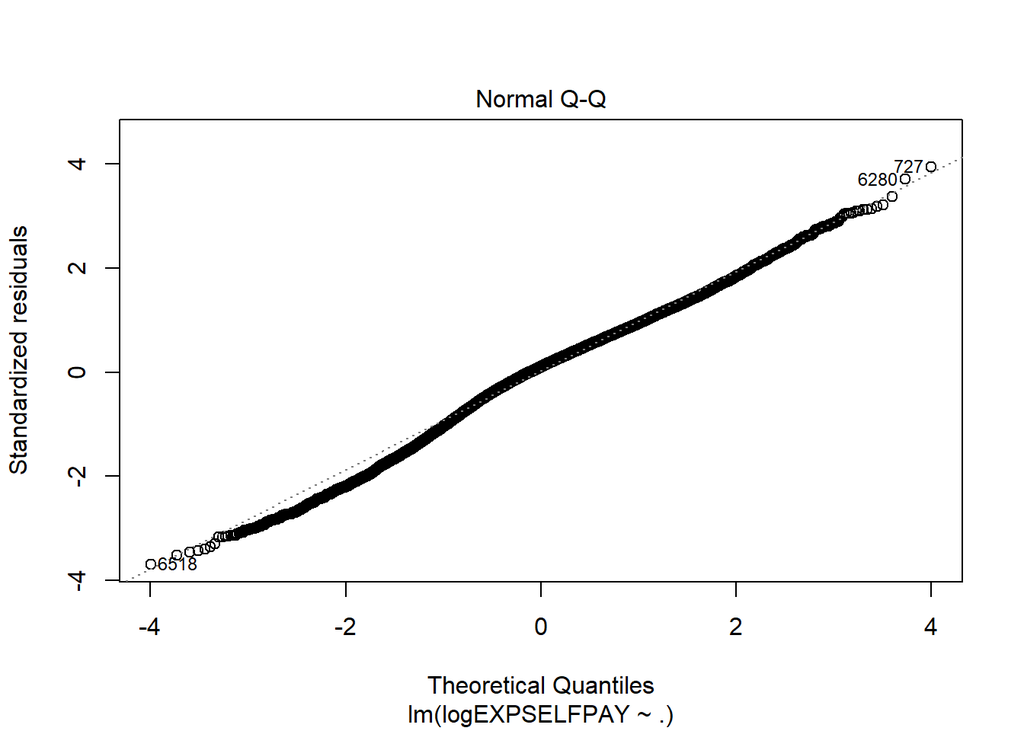

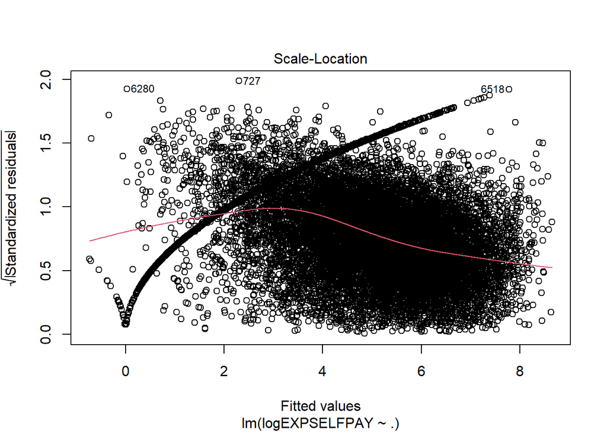

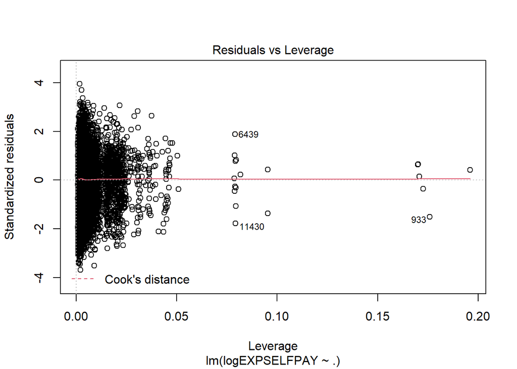

```r
plot(reg1)
```

Based on our model evaluation, we can see that there are 6 outliers that should be removed from the dataset.

```r
outliers <- rownames(d) %in% c(727, 933, 6280, 6439, 6518, 11430)
d <- d[!outliers, ]
# re-run the regression
reg1 <- lm(logEXPSELFPAY~., data=d)
summary(reg1)
```

```
##
## Call:
## lm(formula = logEXPSELFPAY ~ ., data = d)
##
## Residuals:
##     Min      1Q  Median      3Q     Max
## -7.3936 -1.2759  0.2165  1.4205  7.0976
##
## Coefficients:
##              Estimate Std. Error t value Pr(>|t|)
## (Intercept) -0.336833   0.318173  -1.059  0.28978
## MARSTAT20    0.097088   0.072216   1.344  0.17884
## MARSTAT30    0.143376   0.054859   2.614  0.00897 **
## MARSTAT40    0.052017   0.115888   0.449  0.65354
## MARSTAT50    0.025545   0.050742   0.503  0.61467
## AGE          0.038254   0.001254  30.516  < 2e-16 ***
## EDUC104     -0.309510   0.493790  -0.627  0.53080
## EDUC105      0.079465   0.469766   0.169  0.86567
## EDUC106      0.369997   0.387274   0.955  0.33940
## EDUC107      0.235456   0.407734   0.577  0.56363
## EDUC108      0.184105   0.392470   0.469  0.63901
## EDUC109      0.088589   0.328456   0.270  0.78738
## EDUC110      0.222272   0.344262   0.646  0.51852
## EDUC111      0.186017   0.315780   0.589  0.55582
## EDUC113      0.279280   0.312287   0.894  0.37117
## EDUC114      0.342303   0.312868   1.094  0.27394
## EDUC115      0.228467   0.312835   0.730  0.46521
## EDUC116      0.204970   0.333924   0.614  0.53934
## EDUC201      0.279075   0.302915   0.921  0.35691
## EDUC202      0.209993   0.313989   0.669  0.50364
## EDUC301      0.466700   0.304714   1.532  0.12564
## EDUC400      0.681484   0.305027   2.234  0.02549 *
## EDUC501      0.703524   0.308247   2.282  0.02248 *
## EDUC503      0.757592   0.325653   2.326  0.02001 *
## EDUC504      0.489941   0.307238   1.595  0.11081
## SEX2         0.320846   0.035162   9.125  < 2e-16 ***
## RACEA200    -0.643069   0.048390 -13.289  < 2e-16 ***
## RACEA310    -0.333959   0.243511  -1.371  0.17026
## RACEA410    -0.749883   0.073630 -10.184  < 2e-16 ***
## RACEA420    -0.060520   0.311964  -0.194  0.84618
```

[output cut: 23 more lines]

```
## POVCAT5      0.974415   0.062354  15.627  < 2e-16 ***
## USCTRVLTIM2  0.027061   0.036319   0.745  0.45622
## USCTRVLTIM3  0.034387   0.063205   0.544  0.58641
## USCTRVLTIM4 -0.117086   0.183277  -0.639  0.52293
## USCTRVLTIM5  0.443091   0.306745   1.444  0.14862
## USCTRVLTIM6  0.388744   0.288248   1.349  0.17747
## HINOTCOV2    1.153164   0.081639  14.125  < 2e-16 ***
## HIPRIVATE2   1.101187   0.044176  24.927  < 2e-16 ***
## ADILCR2      0.444780   0.040111  11.089  < 2e-16 ***
## ---
## Signif. codes:  0 '***' 0.001 '**' 0.01 '*' 0.05 '.' 0.1 ' ' 1
##
## Residual standard error: 2.106 on 15421 degrees of freedom
## Multiple R-squared:  0.3819, Adjusted R-squared:  0.3795
## F-statistic: 156.2 on 61 and 15421 DF,  p-value: < 2.2e-16
```

Now, we check to see if there exists any variables that are linearly dependant.

```r
ld.vars <- attributes(alias(reg1)$Complete)$dimnames[[1]]
ld.vars
```

[output not shown]

There are none; we are clear to proceed.

Now, we check to see if there are any variables with a high VIF score, indicating the presence of a multicollinearity issue. The pre-set VIF threshold is 5. We will use the AIC criteration when computing the VIF score.

```r
library("car")
vif(reg1)
```

```
##                GVIF Df GVIF^(1/(2*Df))
## MARSTAT    2.189345  4        1.102908
## AGE        2.051986  1        1.432475
## EDUC       1.888195 19        1.016868
## SEX        1.059561  1        1.029350
## RACEA      1.299983 11        1.011996
## HISPETH    1.481428  7        1.028470
## VISITYRNO  1.351854  6        1.025441
## POVCAT     1.704538  4        1.068934
## USCTRVLTIM 1.046272  5        1.004534
## HINOTCOV   1.203542  1        1.097061
## HIPRIVATE  1.622140  1        1.273633
## ADILCR     1.148666  1        1.071759
```

No variables have a VIF score over 5, so we are not concerned about any severe multicollinearity issues.

Now, we will perform stepwise regression to determine if all features produce an optimal first-order model for predicting the outcome variable.

```r
step(reg1)
```

```
## Start:  AIC=23120.18
## logEXPSELFPAY ~ MARSTAT + AGE + EDUC + SEX + RACEA + HISPETH +
##     VISITYRNO + POVCAT + USCTRVLTIM + HINOTCOV + HIPRIVATE +
##     ADILCR
##
##              Df Sum of Sq   RSS   AIC
## - USCTRVLTIM  5      21.6 68396 23115
## - MARSTAT     4      33.2 68407 23120
## <none>                    68374 23120
## - EDUC       19     429.1 68803 23179
## - SEX         1     369.2 68743 23202
## - ADILCR      1     545.2 68919 23241
## - HISPETH     7     881.0 69255 23304
## - HINOTCOV    1     884.6 69259 23317
## - RACEA      11    1163.9 69538 23360
## - POVCAT      4    1207.5 69582 23383
## - HIPRIVATE   1    2755.1 71129 23730
## - AGE         1    4129.0 72503 24026
## - VISITYRNO   6    7313.5 75688 24682
##
## Step:  AIC=23115.08
## logEXPSELFPAY ~ MARSTAT + AGE + EDUC + SEX + RACEA + HISPETH +
##     VISITYRNO + POVCAT + HINOTCOV + HIPRIVATE + ADILCR
##
##             Df Sum of Sq   RSS   AIC
## - MARSTAT    4      33.6 68429 23115
## <none>                   68396 23115
## - EDUC      19     431.5 68827 23174
## - SEX        1     369.7 68766 23197
## - ADILCR     1     546.7 68943 23236
## - HISPETH    7     879.0 69275 23299
## - HINOTCOV   1     885.6 69281 23312
## - RACEA     11    1160.8 69557 23354
## - POVCAT     4    1202.4 69598 23377
## - HIPRIVATE  1    2755.8 71152 23725
## - AGE        1    4165.8 72562 24029
## - VISITYRNO  6    7330.7 75727 24680
##
## Step:  AIC=23114.68
## logEXPSELFPAY ~ AGE + EDUC + SEX + RACEA + HISPETH + VISITYRNO +
##     POVCAT + HINOTCOV + HIPRIVATE + ADILCR
##
##             Df Sum of Sq   RSS   AIC
## <none>                   68429 23115
## - EDUC      19     435.7 68865 23175
## - SEX        1     401.7 68831 23203
## - ADILCR     1     552.5 68982 23237
## - HISPETH    7     897.7 69327 23303
## - HINOTCOV   1     889.4 69319 23313
## - RACEA     11    1172.0 69601 23356
## - POVCAT     4    1180.7 69610 23372
## - HIPRIVATE  1    2764.9 71194 23726
## - AGE        1    6666.5 75096 24552
## - VISITYRNO  6    7337.5 75767 24680
```

```
##
## Call:
## lm(formula = logEXPSELFPAY ~ AGE + EDUC + SEX + RACEA + HISPETH +
##     VISITYRNO + POVCAT + HINOTCOV + HIPRIVATE + ADILCR, data = d)
##
## Coefficients:
## (Intercept)          AGE      EDUC104      EDUC105      EDUC106      EDUC107
##    -0.30424      0.03885     -0.32414      0.06918      0.36077      0.21693
##     EDUC108      EDUC109      EDUC110      EDUC111      EDUC113      EDUC114
##     0.17168      0.07184      0.22394      0.18520      0.27924      0.34297
##     EDUC115      EDUC116      EDUC201      EDUC202      EDUC301      EDUC400
##     0.22613      0.20200      0.27569      0.21564      0.46922      0.67863
##     EDUC501      EDUC503      EDUC504         SEX2     RACEA200     RACEA310
##     0.69866      0.74499      0.49409      0.33084     -0.63743     -0.33909
##    RACEA410     RACEA420     RACEA610     RACEA611     RACEA612     RACEA613
##    -0.76063     -0.07863     -0.93793      0.14938      0.23437     -0.65477
##    RACEA614     RACEA615     RACEA616    HISPETH20    HISPETH30    HISPETH40
##    -0.14912     -0.07008      1.88076     -0.61733     -0.78038     -1.10508
##   HISPETH50    HISPETH60    HISPETH61    HISPETH70  VISITYRNO10  VISITYRNO21
##    -0.80064     -0.29566     -0.63906     -0.17322      1.00371      1.47831
## VISITYRNO22  VISITYRNO31  VISITYRNO33  VISITYRNO40      POVCAT2      POVCAT3
##     1.72020      1.91914      2.04243      2.35173      0.27648      0.42216
##     POVCAT4      POVCAT5    HINOTCOV2   HIPRIVATE2      ADILCR2
##     0.76559      0.95029      1.15206      1.09529      0.44759
```

The new model is as follows:

```r
remove.cols <- colnames(d) %in% c("USCTRVLTIM", "MARSTAT")
d <- d[,!remove.cols]

reg2 <- lm(logEXPSELFPAY ~ ., data=d)
summary(reg2)
```

```
##
## Call:
## lm(formula = logEXPSELFPAY ~ ., data = d)
##
## Residuals:
##     Min      1Q  Median      3Q     Max
## -7.5735 -1.2775  0.2127  1.4181  7.1023
##
## Coefficients:
##              Estimate Std. Error t value Pr(>|t|)
## (Intercept) -0.304237   0.311458  -0.977  0.32868
## AGE          0.038846   0.001002  38.771  < 2e-16 ***
## EDUC104     -0.324135   0.493552  -0.657  0.51136
## EDUC105      0.069177   0.469682   0.147  0.88291
## EDUC106      0.360773   0.386944   0.932  0.35116
## EDUC107      0.216932   0.407584   0.532  0.59457
## EDUC108      0.171681   0.392160   0.438  0.66155
## EDUC109      0.071842   0.328135   0.219  0.82670
## EDUC110      0.223939   0.343957   0.651  0.51501
## EDUC111      0.185196   0.315563   0.587  0.55729
## EDUC113      0.279241   0.312031   0.895  0.37085
## EDUC114      0.342968   0.312574   1.097  0.27256
## EDUC115      0.226129   0.312561   0.723  0.46940
## EDUC116      0.202003   0.333591   0.606  0.54483
## EDUC201      0.275690   0.302525   0.911  0.36215
## EDUC202      0.215645   0.313531   0.688  0.49159
## EDUC301      0.469218   0.304317   1.542  0.12313
## EDUC400      0.678626   0.304569   2.228  0.02588 *
## EDUC501      0.698657   0.307815   2.270  0.02324 *
## EDUC503      0.744990   0.325216   2.291  0.02199 *
## EDUC504      0.494094   0.306757   1.611  0.10727
## SEX2         0.330838   0.034762   9.517  < 2e-16 ***
## RACEA200    -0.637431   0.047990 -13.282  < 2e-16 ***
## RACEA310    -0.339085   0.243322  -1.394  0.16347
## RACEA410    -0.760628   0.073475 -10.352  < 2e-16 ***
## RACEA420    -0.078634   0.311857  -0.252  0.80093
## RACEA610    -0.937932   0.440052  -2.131  0.03307 *
## RACEA611     0.149382   0.637456   0.234  0.81472
## RACEA612     0.234367   0.255155   0.919  0.35836
## RACEA613    -0.654769   0.280540  -2.334  0.01961 *
```

[output cut: 14 more lines]

```
## VISITYRNO33  2.042427   0.064136  31.845  < 2e-16 ***
## VISITYRNO40  2.351730   0.075046  31.337  < 2e-16 ***
## POVCAT2      0.276484   0.087207   3.170  0.00153 **
## POVCAT3      0.422158   0.063475   6.651 3.01e-11 ***
## POVCAT4      0.765591   0.058654  13.053  < 2e-16 ***
## POVCAT5      0.950292   0.061598  15.427  < 2e-16 ***
## HINOTCOV2    1.152064   0.081350  14.162  < 2e-16 ***
## HIPRIVATE2   1.095293   0.043866  24.969  < 2e-16 ***
## ADILCR2      0.447586   0.040099  11.162  < 2e-16 ***
## ---
## Signif. codes:  0 '***' 0.001 '**' 0.01 '*' 0.05 '.' 0.1 ' ' 1
##
## Residual standard error: 2.106 on 15430 degrees of freedom
## Multiple R-squared:  0.3814, Adjusted R-squared:  0.3793
## F-statistic:   183 on 52 and 15430 DF,  p-value: < 2.2e-16
```

The adjusted R-squared of Model2 is 0.3794. The coefficient values of Model2 suggest several things: As age increases, the logged expected value of healthcare payments increases. This makes intuitive sense; generally speaking, as an individual ages, more healthcare issues arise.

With respect to race and ethnicity: per the model, those who identify as Black or Asian on average are expected to pay less than White individuals for healthcare, and those who identify as some form of Hispanic also are expected to pay less for healthcare. While the coefficients suggest these groups are expected to pay less for healthcare, I am inclined to think it has more to do with the fact that over 70% of the dataset is based on white individuals, so we cannot really make any strong claims about whether or not those individuals really are expected to pay less.

Sex also was deemed to be a significant predictor, with the model suggesting that those who are female are, on average, expected to pay more for healthcare. This could be due to several reasons, one of which being that there are many specialty healthcare services for people who are female that are not considered to be a part of general healthcare practice. In these cases, seeing a specialist for what are colloquially known as “woman’s health services” would incur more costs.

As the number of trips to the doctor increases, the expected amount of healthcare payments also increases.

As a unit is further from the poverty line, or, as an individual makes more money, the more they are expected to pay for healthcare. This could be explained by the fact that those who make more are less likely to be on government funded healthcare insurance programs, like Medicaid.

Individuals who have no insurance coverage are, on average, expected to pay more for healthcare. This makes sense as none of the healthcare costs are covered by insurance if an individual does not have insurance.

Lastly, having a condition needing immediate attention in last 12 months leads to having an increased expected healthcare payment amount. This could make sense as emergency services are not known for being cheap.

```r
library("car")
vif(reg2)
```

```
##               GVIF Df GVIF^(1/(2*Df))
## AGE       1.310574  1        1.144803
## EDUC      1.787484 19        1.015402
## SEX       1.035348  1        1.017521
## RACEA     1.255611 11        1.010400
## HISPETH   1.460583  7        1.027429
## VISITYRNO 1.343787  6        1.024930
## POVCAT    1.651248  4        1.064698
## HINOTCOV  1.194788  1        1.093064
## HIPRIVATE 1.599098  1        1.264554
## ADILCR    1.147709  1        1.071312
```

Model 2 is the best first-order model, given our current data and predictors.

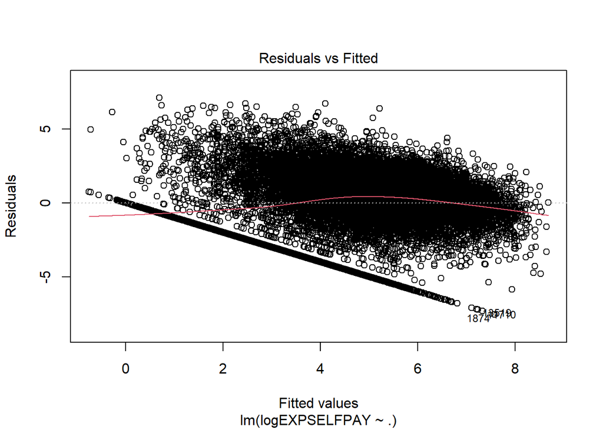

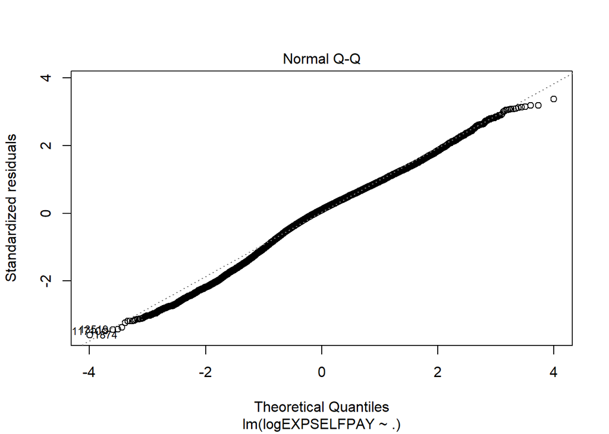

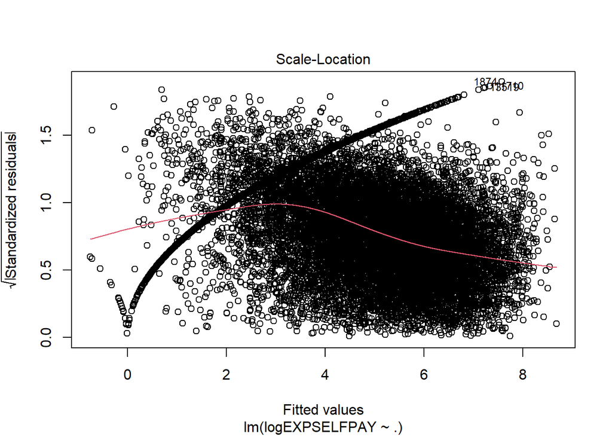

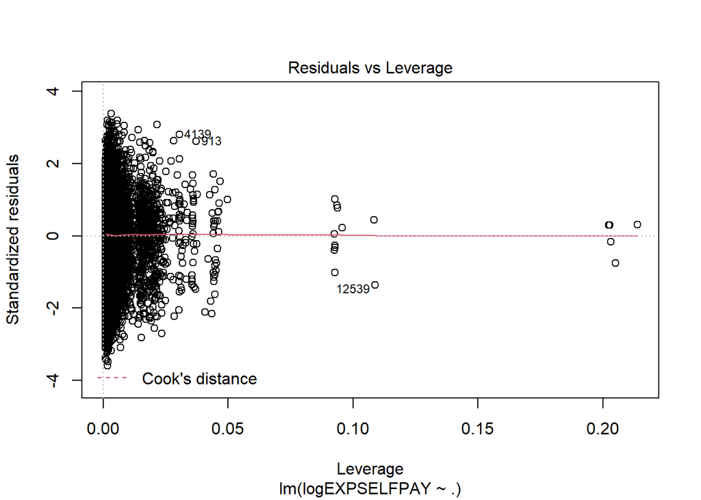

```r
plot(reg2)
```

The residuals do not appear to be random, which suggests a non-linear model may be prefered for the dataset. The Normal Q-Q plot suggests that we can assume the data mostly fits a normal distribution, with some exceptions at the extreme ends.